# Risk Factor Analysis

## Outcome Variable

**Outcome Variable:** wasted

## Predictor Variables

**Intervention Variable:** cleanck

**Adjustment Set:**

- arm
- sex
- W_mage
- meducyrs
- feducyrs
- hhwealth_quart
- W_nrooms
- W_nhh
- W_nchldlt5
- trth2o
- impfloor
- delta_meducyrs
- delta_feducyrs
- delta_hhwealth_quart
- delta_W_nrooms
- delta_W_nhh
- delta_W_nchldlt5
- delta_trth2o
- delta_impfloor

## Stratifying Variables

The analysis was stratified on these variable(s):

- agecat
- studyid
- country

## Data Summary

| agecat | studyid | country | cleanck | wasted | n_cell | n |
| --- | --- | --- | --- | --- | --- | --- |
| Birth | ki0047075b-MAL-ED | PERU | 1 | 0 | 1 | 2 |
| Birth | ki0047075b-MAL-ED | PERU | 1 | 1 | 0 | 2 |
| Birth | ki0047075b-MAL-ED | PERU | 0 | 0 | 1 | 2 |
| Birth | ki0047075b-MAL-ED | PERU | 0 | 1 | 0 | 2 |
| Birth | ki0047075b-MAL-ED | SOUTH AFRICA | 1 | 0 | 0 | 2 |
| Birth | ki0047075b-MAL-ED | SOUTH AFRICA | 1 | 1 | 1 | 2 |
| Birth | ki0047075b-MAL-ED | SOUTH AFRICA | 0 | 0 | 1 | 2 |
| Birth | ki0047075b-MAL-ED | SOUTH AFRICA | 0 | 1 | 0 | 2 |
| Birth | ki1000108-CMC-V-BCS-2002 | INDIA | 1 | 0 | 33 | 88 |
| Birth | ki1000108-CMC-V-BCS-2002 | INDIA | 1 | 1 | 4 | 88 |
| Birth | ki1000108-CMC-V-BCS-2002 | INDIA | 0 | 0 | 41 | 88 |
| Birth | ki1000108-CMC-V-BCS-2002 | INDIA | 0 | 1 | 10 | 88 |
| Birth | ki1000108-IRC | INDIA | 1 | 0 | 157 | 337 |
| Birth | ki1000108-IRC | INDIA | 1 | 1 | 41 | 337 |
| Birth | ki1000108-IRC | INDIA | 0 | 0 | 91 | 337 |
| Birth | ki1000108-IRC | INDIA | 0 | 1 | 48 | 337 |
| Birth | ki1017093c-NIH-Crypto | BANGLADESH | 1 | 0 | 10 | 17 |
| Birth | ki1017093c-NIH-Crypto | BANGLADESH | 1 | 1 | 1 | 17 |
| Birth | ki1017093c-NIH-Crypto | BANGLADESH | 0 | 0 | 5 | 17 |
| Birth | ki1017093c-NIH-Crypto | BANGLADESH | 0 | 1 | 1 | 17 |
| 6 months | ki0047075b-MAL-ED | SOUTH AFRICA | 1 | 0 | 1 | 1 |
| 6 months | ki0047075b-MAL-ED | SOUTH AFRICA | 1 | 1 | 0 | 1 |
| 6 months | ki0047075b-MAL-ED | SOUTH AFRICA | 0 | 0 | 0 | 1 |
| 6 months | ki0047075b-MAL-ED | SOUTH AFRICA | 0 | 1 | 0 | 1 |
| 6 months | ki1000108-CMC-V-BCS-2002 | INDIA | 1 | 0 | 146 | 368 |
| 6 months | ki1000108-CMC-V-BCS-2002 | INDIA | 1 | 1 | 16 | 368 |
| 6 months | ki1000108-CMC-V-BCS-2002 | INDIA | 0 | 0 | 176 | 368 |
| 6 months | ki1000108-CMC-V-BCS-2002 | INDIA | 0 | 1 | 30 | 368 |
| 6 months | ki1000108-IRC | INDIA | 1 | 0 | 195 | 398 |
| 6 months | ki1000108-IRC | INDIA | 1 | 1 | 34 | 398 |
| 6 months | ki1000108-IRC | INDIA | 0 | 0 | 150 | 398 |
| 6 months | ki1000108-IRC | INDIA | 0 | 1 | 19 | 398 |
| 6 months | ki1017093b-PROVIDE | BANGLADESH | 1 | 0 | 466 | 582 |
| 6 months | ki1017093b-PROVIDE | BANGLADESH | 1 | 1 | 15 | 582 |
| 6 months | ki1017093b-PROVIDE | BANGLADESH | 0 | 0 | 92 | 582 |
| 6 months | ki1017093b-PROVIDE | BANGLADESH | 0 | 1 | 9 | 582 |
| 6 months | ki1017093c-NIH-Crypto | BANGLADESH | 1 | 0 | 321 | 545 |
| 6 months | ki1017093c-NIH-Crypto | BANGLADESH | 1 | 1 | 8 | 545 |
| 6 months | ki1017093c-NIH-Crypto | BANGLADESH | 0 | 0 | 211 | 545 |
| 6 months | ki1017093c-NIH-Crypto | BANGLADESH | 0 | 1 | 5 | 545 |
| 6 months | ki1113344-GMS-Nepal | NEPAL | 1 | 0 | 8 | 504 |
| 6 months | ki1113344-GMS-Nepal | NEPAL | 1 | 1 | 0 | 504 |
| 6 months | ki1113344-GMS-Nepal | NEPAL | 0 | 0 | 450 | 504 |
| 6 months | ki1113344-GMS-Nepal | NEPAL | 0 | 1 | 46 | 504 |
| 24 months | ki0047075b-MAL-ED | SOUTH AFRICA | 1 | 0 | 1 | 1 |
| 24 months | ki0047075b-MAL-ED | SOUTH AFRICA | 1 | 1 | 0 | 1 |
| 24 months | ki0047075b-MAL-ED | SOUTH AFRICA | 0 | 0 | 0 | 1 |
| 24 months | ki0047075b-MAL-ED | SOUTH AFRICA | 0 | 1 | 0 | 1 |
| 24 months | ki1000108-CMC-V-BCS-2002 | INDIA | 1 | 0 | 157 | 372 |
| 24 months | ki1000108-CMC-V-BCS-2002 | INDIA | 1 | 1 | 6 | 372 |
| 24 months | ki1000108-CMC-V-BCS-2002 | INDIA | 0 | 0 | 192 | 372 |
| 24 months | ki1000108-CMC-V-BCS-2002 | INDIA | 0 | 1 | 17 | 372 |
| 24 months | ki1000108-IRC | INDIA | 1 | 0 | 216 | 400 |
| 24 months | ki1000108-IRC | INDIA | 1 | 1 | 15 | 400 |
| 24 months | ki1000108-IRC | INDIA | 0 | 0 | 153 | 400 |
| 24 months | ki1000108-IRC | INDIA | 0 | 1 | 16 | 400 |
| 24 months | ki1017093b-PROVIDE | BANGLADESH | 1 | 0 | 436 | 578 |
| 24 months | ki1017093b-PROVIDE | BANGLADESH | 1 | 1 | 44 | 578 |
| 24 months | ki1017093b-PROVIDE | BANGLADESH | 0 | 0 | 77 | 578 |
| 24 months | ki1017093b-PROVIDE | BANGLADESH | 0 | 1 | 21 | 578 |
| 24 months | ki1017093c-NIH-Crypto | BANGLADESH | 1 | 0 | 185 | 410 |
| 24 months | ki1017093c-NIH-Crypto | BANGLADESH | 1 | 1 | 14 | 410 |
| 24 months | ki1017093c-NIH-Crypto | BANGLADESH | 0 | 0 | 193 | 410 |
| 24 months | ki1017093c-NIH-Crypto | BANGLADESH | 0 | 1 | 18 | 410 |
| 24 months | ki1113344-GMS-Nepal | NEPAL | 1 | 0 | 6 | 445 |
| 24 months | ki1113344-GMS-Nepal | NEPAL | 1 | 1 | 1 | 445 |
| 24 months | ki1113344-GMS-Nepal | NEPAL | 0 | 0 | 359 | 445 |
| 24 months | ki1113344-GMS-Nepal | NEPAL | 0 | 1 | 79 | 445 |

The following strata were considered:

- agecat: 24 months, studyid: ki0047075b-MAL-ED, country: SOUTH AFRICA
- agecat: 24 months, studyid: ki1000108-CMC-V-BCS-2002, country: INDIA
- agecat: 24 months, studyid: ki1000108-IRC, country: INDIA
- agecat: 24 months, studyid: ki1017093b-PROVIDE, country: BANGLADESH
- agecat: 24 months, studyid: ki1017093c-NIH-Crypto, country: BANGLADESH
- agecat: 24 months, studyid: ki1113344-GMS-Nepal, country: NEPAL
- agecat: 6 months, studyid: ki0047075b-MAL-ED, country: SOUTH AFRICA
- agecat: 6 months, studyid: ki1000108-CMC-V-BCS-2002, country: INDIA
- agecat: 6 months, studyid: ki1000108-IRC, country: INDIA
- agecat: 6 months, studyid: ki1017093b-PROVIDE, country: BANGLADESH
- agecat: 6 months, studyid: ki1017093c-NIH-Crypto, country: BANGLADESH
- agecat: 6 months, studyid: ki1113344-GMS-Nepal, country: NEPAL
- agecat: Birth, studyid: ki0047075b-MAL-ED, country: PERU
- agecat: Birth, studyid: ki0047075b-MAL-ED, country: SOUTH AFRICA
- agecat: Birth, studyid: ki1000108-CMC-V-BCS-2002, country: INDIA
- agecat: Birth, studyid: ki1000108-IRC, country: INDIA
- agecat: Birth, studyid: ki1017093c-NIH-Crypto, country: BANGLADESH

### Dropped Strata

Some strata were dropped due to rare outcomes:

- agecat: Birth, studyid: ki0047075b-MAL-ED, country: PERU
- agecat: Birth, studyid: ki0047075b-MAL-ED, country: SOUTH AFRICA
- agecat: Birth, studyid: ki1000108-CMC-V-BCS-2002, country: INDIA
- agecat: Birth, studyid: ki1017093c-NIH-Crypto, country: BANGLADESH
- agecat: 6 months, studyid: ki0047075b-MAL-ED, country: SOUTH AFRICA
- agecat: 6 months, studyid: ki1113344-GMS-Nepal, country: NEPAL
- agecat: 24 months, studyid: ki0047075b-MAL-ED, country: SOUTH AFRICA
- agecat: 24 months, studyid: ki1113344-GMS-Nepal, country: NEPAL

## Methods Detail

We’re interested in the causal parameters $E[Y_a]$ for all values of $a \in \mathcal{A}$. These parameters represent the mean outcome if, possibly contrary to fact, we intervened to set all units to have $A=a$. Under the randomization and positivity assumptions, these are identified by the statistical parameters $\psi_a=E_W[E_{Y|A,W}(Y|A=a,W)]$. In addition, we’re interested in the mean of $Y$, $E[Y]$ under no intervention (the observed mean). We will estimate these parameters by using SuperLearner to fit the relevant likelihood factors – $E_{Y|A,W}(Y|A=a,W)$ and $p(A=a|W)$, and then updating our likelihood fit using a joint TMLE.

For unadjusted analyses ($W=\{\}$), initial likelihoods were estimated using Lrnr_glm to estimate the simple $E(Y|A)$ and Lrnr_mean to estimate $p(A)$. For adjusted analyses, a small library containing Lrnr_glmnet, Lrnr_xgboost, and Lrnr_mean was used.

Having estimated these parameters, we will then use the delta method to estimate relative risks and attributable risks relative to a prespecified baseline level of $A$.

# Results Detail

## Results Plots

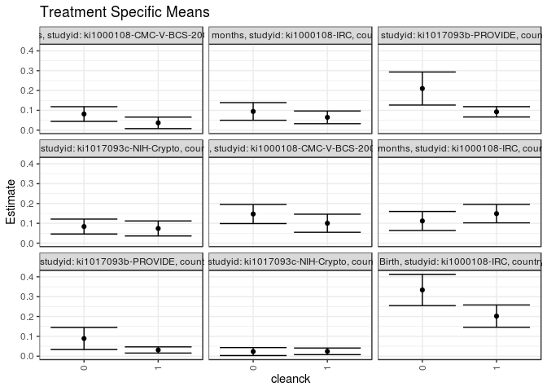

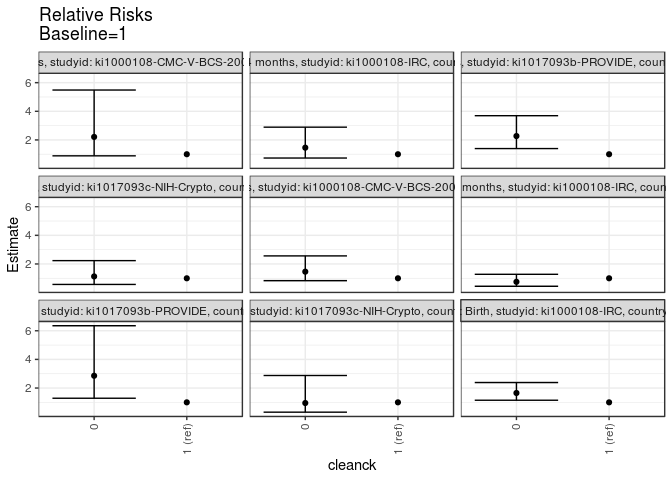

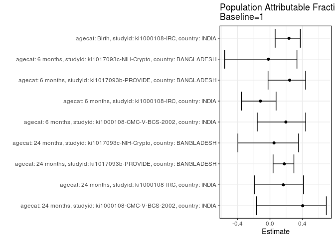

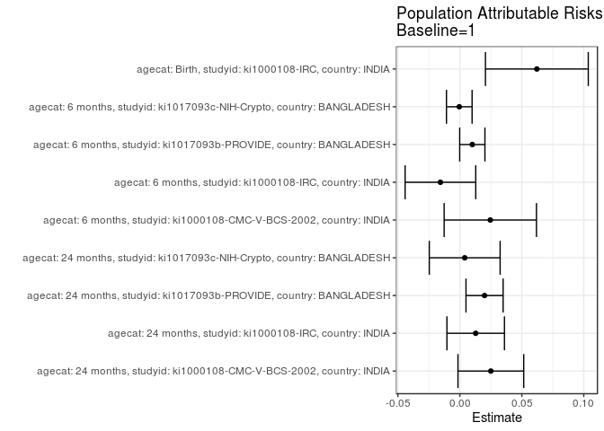

## Results Table

### Parameter: TSM

| agecat | studyid | country | intervention_level | baseline_level | estimate | ci_lower | ci_upper |
| --- | --- | --- | --- | --- | --- | --- | --- |
| Birth | ki1000108-IRC | INDIA | 1 | NA | 0.2019449 | 0.1457379 | 0.2581519 |
| Birth | ki1000108-IRC | INDIA | 0 | NA | 0.3338916 | 0.2549505 | 0.4128326 |
| 6 months | ki1000108-CMC-V-BCS-2002 | INDIA | 1 | NA | 0.1004294 | 0.0548637 | 0.1459951 |
| 6 months | ki1000108-CMC-V-BCS-2002 | INDIA | 0 | NA | 0.1469206 | 0.0987649 | 0.1950763 |
| 6 months | ki1000108-IRC | INDIA | 1 | NA | 0.1488398 | 0.1024491 | 0.1952305 |
| 6 months | ki1000108-IRC | INDIA | 0 | NA | 0.1119996 | 0.0641303 | 0.1598689 |
| 6 months | ki1017093b-PROVIDE | BANGLADESH | 1 | NA | 0.0311850 | 0.0156382 | 0.0467319 |
| 6 months | ki1017093b-PROVIDE | BANGLADESH | 0 | NA | 0.0891089 | 0.0334987 | 0.1447191 |
| 6 months | ki1017093c-NIH-Crypto | BANGLADESH | 1 | NA | 0.0243161 | 0.0076570 | 0.0409752 |
| 6 months | ki1017093c-NIH-Crypto | BANGLADESH | 0 | NA | 0.0231481 | 0.0030761 | 0.0432202 |
| 24 months | ki1000108-CMC-V-BCS-2002 | INDIA | 1 | NA | 0.0368098 | 0.0078646 | 0.0657550 |
| 24 months | ki1000108-CMC-V-BCS-2002 | INDIA | 0 | NA | 0.0813397 | 0.0442299 | 0.1184495 |
| 24 months | ki1000108-IRC | INDIA | 1 | NA | 0.0647152 | 0.0327099 | 0.0967204 |
| 24 months | ki1000108-IRC | INDIA | 0 | NA | 0.0944306 | 0.0498483 | 0.1390130 |
| 24 months | ki1017093b-PROVIDE | BANGLADESH | 1 | NA | 0.0925212 | 0.0665313 | 0.1185112 |
| 24 months | ki1017093b-PROVIDE | BANGLADESH | 0 | NA | 0.2100433 | 0.1266219 | 0.2934647 |
| 24 months | ki1017093c-NIH-Crypto | BANGLADESH | 1 | NA | 0.0741292 | 0.0362864 | 0.1119721 |
| 24 months | ki1017093c-NIH-Crypto | BANGLADESH | 0 | NA | 0.0837924 | 0.0461413 | 0.1214435 |

### Parameter: E(Y)

| agecat | studyid | country | intervention_level | baseline_level | estimate | ci_lower | ci_upper |
| --- | --- | --- | --- | --- | --- | --- | --- |
| Birth | ki1000108-IRC | INDIA | NA | NA | 0.2640950 | 0.2169571 | 0.3112328 |
| 6 months | ki1000108-CMC-V-BCS-2002 | INDIA | NA | NA | 0.1250000 | 0.0911644 | 0.1588356 |
| 6 months | ki1000108-IRC | INDIA | NA | NA | 0.1331658 | 0.0997450 | 0.1665867 |
| 6 months | ki1017093b-PROVIDE | BANGLADESH | NA | NA | 0.0412371 | 0.0250690 | 0.0574052 |
| 6 months | ki1017093c-NIH-Crypto | BANGLADESH | NA | NA | 0.0238532 | 0.0110305 | 0.0366759 |
| 24 months | ki1000108-CMC-V-BCS-2002 | INDIA | NA | NA | 0.0618280 | 0.0373207 | 0.0863352 |
| 24 months | ki1000108-IRC | INDIA | NA | NA | 0.0775000 | 0.0512641 | 0.1037359 |
| 24 months | ki1017093b-PROVIDE | BANGLADESH | NA | NA | 0.1124567 | 0.0866788 | 0.1382347 |
| 24 months | ki1017093c-NIH-Crypto | BANGLADESH | NA | NA | 0.0780488 | 0.0520518 | 0.1040458 |

### Parameter: RR

| agecat | studyid | country | intervention_level | baseline_level | estimate | ci_lower | ci_upper |
| --- | --- | --- | --- | --- | --- | --- | --- |
| Birth | ki1000108-IRC | INDIA | 1 | 1 | 1.0000000 | 1.0000000 | 1.000000 |
| Birth | ki1000108-IRC | INDIA | 0 | 1 | 1.6533792 | 1.1464659 | 2.384426 |
| 6 months | ki1000108-CMC-V-BCS-2002 | INDIA | 1 | 1 | 1.0000000 | 1.0000000 | 1.000000 |
| 6 months | ki1000108-CMC-V-BCS-2002 | INDIA | 0 | 1 | 1.4629240 | 0.8346835 | 2.564021 |
| 6 months | ki1000108-IRC | INDIA | 1 | 1 | 1.0000000 | 1.0000000 | 1.000000 |
| 6 months | ki1000108-IRC | INDIA | 0 | 1 | 0.7524839 | 0.4431535 | 1.277734 |
| 6 months | ki1017093b-PROVIDE | BANGLADESH | 1 | 1 | 1.0000000 | 1.0000000 | 1.000000 |
| 6 months | ki1017093b-PROVIDE | BANGLADESH | 0 | 1 | 2.8574257 | 1.2855300 | 6.351374 |
| 6 months | ki1017093c-NIH-Crypto | BANGLADESH | 1 | 1 | 1.0000000 | 1.0000000 | 1.000000 |
| 6 months | ki1017093c-NIH-Crypto | BANGLADESH | 0 | 1 | 0.9519676 | 0.3152693 | 2.874502 |
| 24 months | ki1000108-CMC-V-BCS-2002 | INDIA | 1 | 1 | 1.0000000 | 1.0000000 | 1.000000 |
| 24 months | ki1000108-CMC-V-BCS-2002 | INDIA | 0 | 1 | 2.2097289 | 0.8902591 | 5.484809 |
| 24 months | ki1000108-IRC | INDIA | 1 | 1 | 1.0000000 | 1.0000000 | 1.000000 |
| 24 months | ki1000108-IRC | INDIA | 0 | 1 | 1.4591736 | 0.7360871 | 2.892575 |
| 24 months | ki1017093b-PROVIDE | BANGLADESH | 1 | 1 | 1.0000000 | 1.0000000 | 1.000000 |
| 24 months | ki1017093b-PROVIDE | BANGLADESH | 0 | 1 | 2.2702166 | 1.3954715 | 3.693292 |
| 24 months | ki1017093c-NIH-Crypto | BANGLADESH | 1 | 1 | 1.0000000 | 1.0000000 | 1.000000 |
| 24 months | ki1017093c-NIH-Crypto | BANGLADESH | 0 | 1 | 1.1303559 | 0.5718905 | 2.234176 |

### Parameter: PAR

| agecat | studyid | country | intervention_level | baseline_level | estimate | ci_lower | ci_upper |
| --- | --- | --- | --- | --- | --- | --- | --- |
| Birth | ki1000108-IRC | INDIA | 1 | NA | 0.0621500 | 0.0206572 | 0.1036428 |
| 6 months | ki1000108-CMC-V-BCS-2002 | INDIA | 1 | NA | 0.0245706 | -0.0126729 | 0.0618141 |
| 6 months | ki1000108-IRC | INDIA | 1 | NA | -0.0156740 | -0.0441749 | 0.0128269 |
| 6 months | ki1017093b-PROVIDE | BANGLADESH | 1 | NA | 0.0100521 | -0.0001260 | 0.0202302 |
| 6 months | ki1017093c-NIH-Crypto | BANGLADESH | 1 | NA | -0.0004629 | -0.0108012 | 0.0098754 |
| 24 months | ki1000108-CMC-V-BCS-2002 | INDIA | 1 | NA | 0.0250181 | -0.0015188 | 0.0515551 |
| 24 months | ki1000108-IRC | INDIA | 1 | NA | 0.0127848 | -0.0104248 | 0.0359945 |
| 24 months | ki1017093b-PROVIDE | BANGLADESH | 1 | NA | 0.0199355 | 0.0049546 | 0.0349164 |
| 24 months | ki1017093c-NIH-Crypto | BANGLADESH | 1 | NA | 0.0039195 | -0.0246648 | 0.0325039 |

### Parameter: PAF

| agecat | studyid | country | intervention_level | baseline_level | estimate | ci_lower | ci_upper |
| --- | --- | --- | --- | --- | --- | --- | --- |
| Birth | ki1000108-IRC | INDIA | 1 | NA | 0.2353321 | 0.0643869 | 0.3750440 |
| 6 months | ki1000108-CMC-V-BCS-2002 | INDIA | 1 | NA | 0.1965647 | -0.1570490 | 0.4421080 |
| 6 months | ki1000108-IRC | INDIA | 1 | NA | -0.1177028 | -0.3518722 | 0.0759041 |
| 6 months | ki1017093b-PROVIDE | BANGLADESH | 1 | NA | 0.2437630 | -0.0235100 | 0.4412420 |
| 6 months | ki1017093c-NIH-Crypto | BANGLADESH | 1 | NA | -0.0194061 | -0.5593435 | 0.3335728 |
| 24 months | ki1000108-CMC-V-BCS-2002 | INDIA | 1 | NA | 0.4046412 | -0.1668932 | 0.6962429 |
| 24 months | ki1000108-IRC | INDIA | 1 | NA | 0.1649657 | -0.1893810 | 0.4137435 |
| 24 months | ki1017093b-PROVIDE | BANGLADESH | 1 | NA | 0.1772726 | 0.0386805 | 0.2958842 |
| 24 months | ki1017093c-NIH-Crypto | BANGLADESH | 1 | NA | 0.0502190 | -0.3962066 | 0.3539037 |